# Examen Tema 3

Se tendrá en cuenta:

- La calidad y eficiencia del código
- Ausencia de (future) warnings y errores
- La calidad visual del gráfico (ejes, estilo, etc.)
- Interpretaciones de los resultados

# Importación de librería y datos

Son datos de jugadores de la Premier League. Solamente hay datos de 3 equipos. Los datos de cada jugador son promedios de rendimiento en su club, no datos por partido.

```python
import pandas as pd
import matplotlib.pyplot as plt
import seaborn as sns
import statsmodels.api as sm
import statsmodels.formula.api as smf
from statsmodels.stats.multicomp import pairwise_tukeyhsd

df = pd.read_csv('EPL_Soccer.csv')
print('Tamaño del dataframe', df.shape)

# muestra
df.head(5)
```

```
Tamaño del dataframe (202, 13)
```

|  | PlayerName | Club | DistanceCovered(InKms) | Goals | MinutestoGoalRatio | ShotsPerGame | AgentCharges | BMI | Cost | PreviousClubCost | Height | Weight | Score |
| --- | --- | --- | --- | --- | --- | --- | --- | --- | --- | --- | --- | --- | --- |
| 0 | Braund, Mr. Owen Harris | MUN | 3.96 | 7.5 | 37.5 | 12.3 | 60 | 20.56 | 109.1 | 63.32 | 195.9 | 78.9 | 19.75 |
| 1 | Allen, Mr. William Henry | MUN | 4.41 | 8.3 | 38.2 | 12.7 | 68 | 20.67 | 102.8 | 58.55 | 189.7 | 74.4 | 21.30 |
| 2 | Moran, Mr. James | MUN | 4.14 | 5.0 | 36.4 | 11.6 | 21 | 21.86 | 104.6 | 55.36 | 177.8 | 69.1 | 19.88 |
| 3 | McCarthy, Mr. Timothy J | MUN | 4.11 | 5.3 | 37.3 | 12.6 | 69 | 21.88 | 126.4 | 57.18 | 185.0 | 74.9 | 23.66 |
| 4 | Palsson, Master. Gosta Leonard | MUN | 4.45 | 6.8 | 41.5 | 14.0 | 29 | 18.96 | 80.3 | 53.20 | 184.6 | 64.6 | 17.64 |

### Significado de cada columna

- **PlayerName**: Nombre del jugador
- **Club**: Club del jugador. Solamente existen datos de 3 clubes.
  - MUN: Manchester United
  - CHE: Chelsea
  - LIV: Liverpool
- **DistanceCovered(InKms)**: Kilómetros promedio recorridos por el jugador en cada partido
- **Goals**: Promedio de goles por partido
- **MinutestoGoalRatio**: Minutos por gol (ratio de minutos por cada gol anotado)
- **ShotsPerGame**: Promedio de tiros por partido
- **AgentCharges**: Honorarios del agente (en cientos de euros)
- **BMI**: Índice de masa corporal
- **Cost**: Costo de cada jugador (en cientos de miles de dólares)
- **PreviousClubCost**: Costo del club anterior (en cientos de miles de dólares)
- **Height**: Altura del jugador en cm
- **Weight**: Peso del jugador en kg
- **Score**: Puntuación promedio por partido

## Ejercicio 1. Tartas (1 puntos)

Crea un gráfico de tartas para visualizar la distribución del gasto en fichajes de cada equipo (columna Cost). Se debe visualizar el % de gasto dentro de cada porción con 1 decimal.

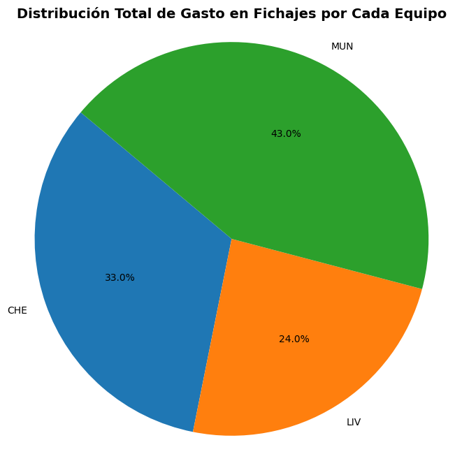

```python
gasto_equipo = df.groupby('Club')['Cost'].sum()

#tarta
plt.rcdefaults()
plt.figure(figsize=(8, 8))
plt.pie(gasto_equipo.values,
        labels=gasto_equipo.index,
        autopct='%1.1f%%',
        startangle=140
)

plt.title('Distribución Total de Gasto en Fichajes por Cada Equipo', fontsize=14, fontweight='bold')
plt.axis('equal')

plt.show()
```

## Ejercicio 2. Diagrama de barras (1.5 puntos)

- Muestra en un diagrama de barras la **media** de distancia corrida 'DistanceCovered(InKms)' por cada club.
- El eje X es el nombre del club.
- El eje Y es la media de la distancia corrida por los jugadores de cada club.
- Pinta el borde de las barras de negro.
- Crea un grid de líneas horizontales.

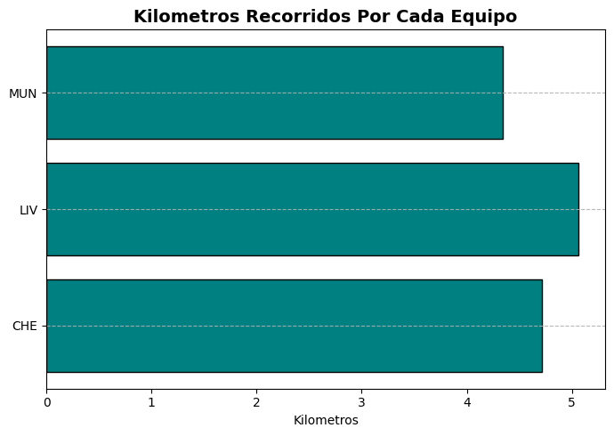

```python
km_equipo = df.groupby('Club')['DistanceCovered(InKms)'].mean()

fig, ax = plt.subplots(figsize=(7, 5))
ax.barh(km_equipo.index, km_equipo.values, color='teal', linewidth=1, edgecolor='black')

# Personalización
plt.rcdefaults()
ax.set_title('Kilometros Recorridos Por Cada Equipo', fontsize=14, fontweight='bold')
ax.set_xlabel('Kilometros')
ax.grid(True, axis='y', linestyle='--', alpha=0.9)

plt.tight_layout()
plt.show()
```

## Ejercicio 3. Histograma (2.5 puntos)

### Gráfica

Crea un histograma con el Score (puntuación). El histograma debe mostrar en el eje Y el número de jugadores que entran dentro de cada rango.

- Se deben crear 15 barras.
- Añade un 'grid' solamente de líneas en el eje y de estilo línea discontinua '--' y semi transparente.
- Añade a cada barra un borde negro
- Añade líneas verticales marcando la media y mediana. De estilo ':', cada una de un color diferente. Que se vea en la legenda.
- Añade un rectángulo vertical con la media +-1std.
- Se debe mostrar legenda.

### Justificación

Comenta la forma de la distribución, ¿es normal?. Basándote en la posición de la media respecto a la mediana en tu gráfico, indica si la distribución tiene sesgo (positivo o negativo) o si es simétrica. Justifica tu respuesta.

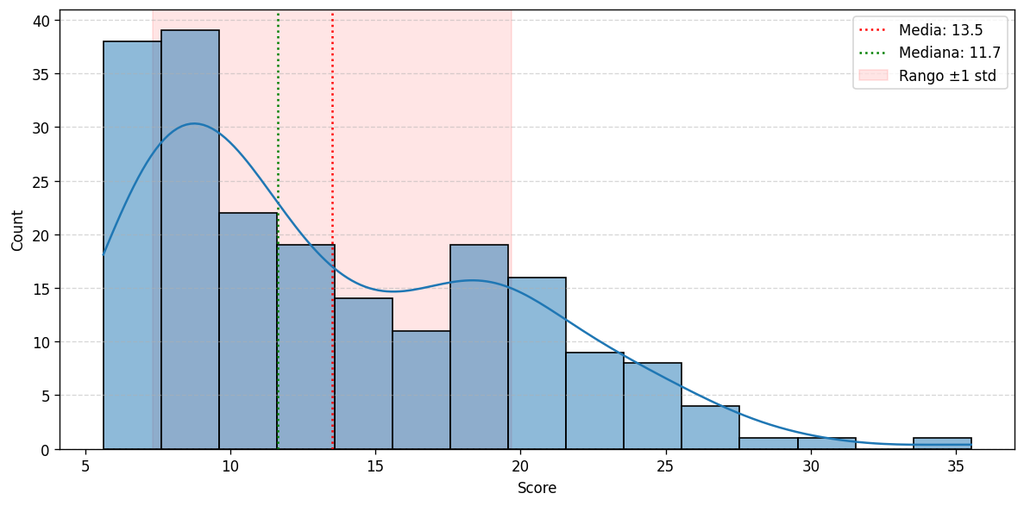

```python
plt.rcdefaults()
plt.rcParams["figure.dpi"] = 120
plt.rcParams["axes.titleweight"] = "bold"
fig, axes = plt.subplots(figsize=(10, 5))

media = df['Score'].mean()
plt.axvline(media, color='red', linestyle=':', label=f'Media: {media:.1f}')
mediana = df['Score'].median()
plt.axvline(mediana, color='green',linestyle=':', label=f'Mediana: {mediana:.1f}')
std = df['Score'].std()
plt.axvspan(media - std, media + std, color='red', alpha=0.1, label='Rango ±1 std')

sns.histplot(x=df['Score'], bins=15, kde=True, ax=axes)
axes.grid(True, linestyle='--',axis='y', alpha=0.5)
plt.tight_layout()
plt.legend()
plt.show()
```

Posee una distribucion con un sesgo hacia la derecha(positivo) que estan inflando la media, por que la mayoria de jugadores tienen una puntuacion "baja pero hay unos pocos con una puntuacion muy alta

## Ejercicio 4. Nube de puntos (2.5 puntos)

Cada punto en celda independiente:

#### 1. Correlación:

- Muestra la correlación entre todas las variables numéricas.
- ¿Qué 4 variables tienen más correlación (positiva o negativa) con Score?

#### 2. Gráfica:

- Muestra en un figure de 2x2 nubes de puntos de Score con cada variable de la respuesta anterior. 'Score' en el eje Y.
- Muestra el centro de la distribución con un '+' en otro color.
- Muestra un cuadro de texto en el gráfico que indique exclusivamente: "Pearson r = valor"

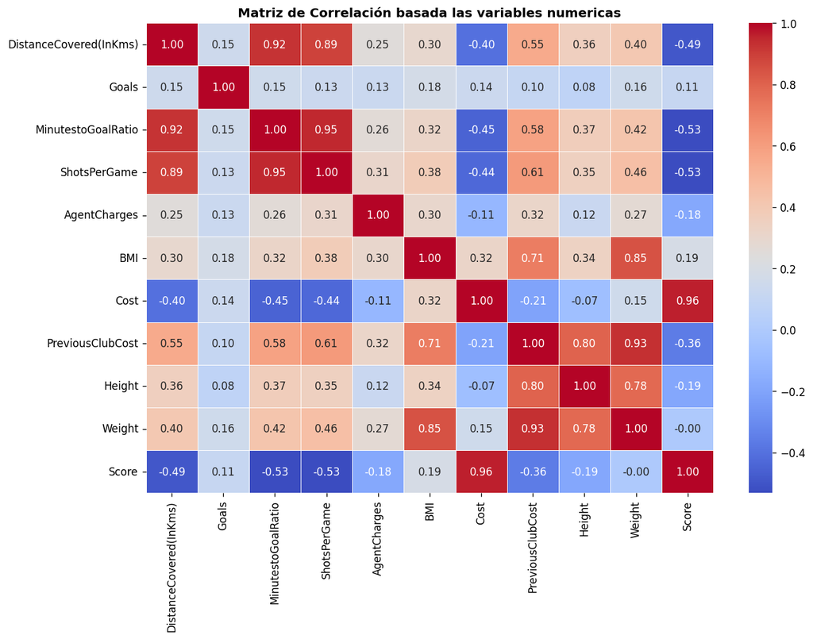

```python
var_numericas = df.select_dtypes(include=['float64', 'int64']).columns.tolist()
matriz_corr = df[var_numericas].corr()

plt.figure(figsize=(12, 8))
sns.heatmap(matriz_corr, annot=True, cmap='coolwarm', fmt=".2f", linewidths=0.5)

plt.title('Matriz de Correlación basada las variables numericas')
plt.show()
```

las variables con mayor correlacion numerica son: Cost(0.96), MinutestoGoalRatio(-0.53), ShotsPerGame(-0.53) y DistanceCovered(InKms)(-0.49)

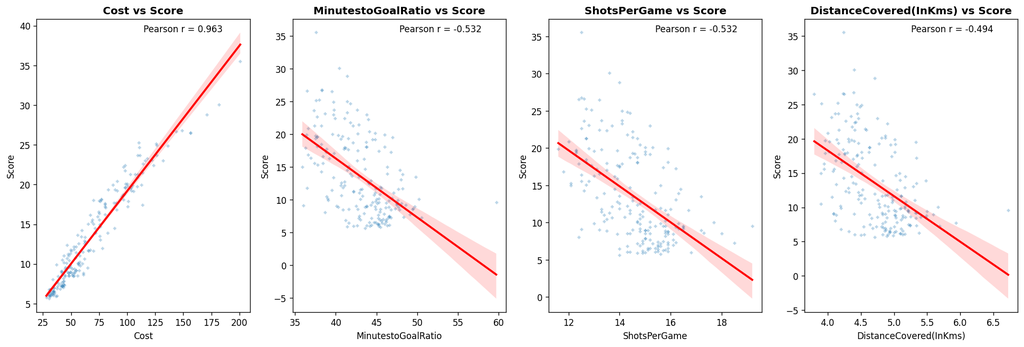

```python
pares_correlacionados = [
    ('Cost', 'Score'),
    ('MinutestoGoalRatio', 'Score'),
    ('ShotsPerGame', 'Score'),
    ('DistanceCovered(InKms)', 'Score')
]

fig, axes = plt.subplots(1, 4, figsize=(20, 6))

for i, (var_x, var_y) in enumerate(pares_correlacionados):
    sns.regplot(x=var_x, y=var_y, data=df,
                ax=axes[i],
                scatter_kws={'alpha':0.3, 's':10},
                line_kws={'color':'red'},
                marker='+')

    # Calculamos la correlación específica para el título
    r = df[var_x].corr(df[var_y])
    axes[i].set_title(f'{var_x} vs {var_y}')
    axes[i].text(0.5, 0.95, f"Pearson r = {r:.3f}", transform=axes[i].transAxes, va="bottom")

plt.show()
```

## Ejercicio 5: Boxplot (2.5 puntos)

#### Gráfica:

- Crea un boxplot de cajas verticales donde el eje Y es el Score y el eje X es el club.
- Pinta una línea de estilo '--' en color rojo con la media de puntuación total (que se vea en legenda).

#### Justificaciones y otros

- Calcula el IQR de cada box y el límite para considerar outliers de cada equipo.
- Muestra los jugadores de cada equipo que son outliers.
- Compara las cajas: qué equipo tiene mayor mediana, en dónde hay más variablidad o dispersión.

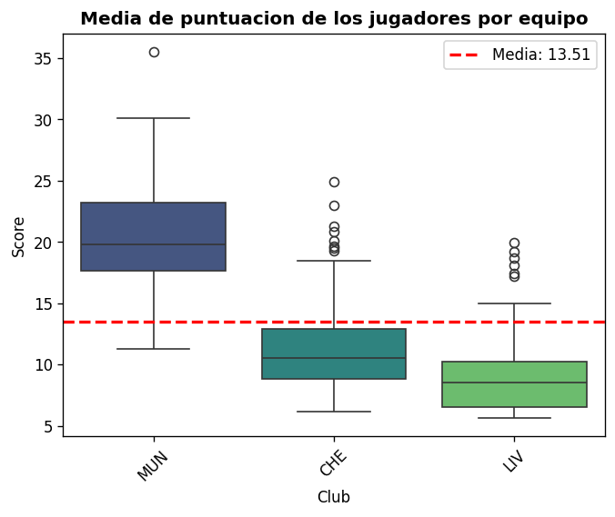

```python
sns.boxplot(x='Club', y='Score', data=df,
            hue='Club', palette='viridis', legend=False)
mean_val = df['Score'].mean()
plt.axhline(mean_val, linestyle="--", linewidth=2, color='red', label=f"Media: {mean_val:.2f}")
plt.title('Media de puntuacion de los jugadores por equipo')
plt.xticks(rotation=45)
plt.legend()
plt.show()
```

```python
equipos = df['Club'].unique()
outlier_report = []

for equipo in equipos:
    data_equipo = df[df['Club'] == equipo]['Score']

    Q1 = data_equipo.quantile(0.25)
    Q3 = data_equipo.quantile(0.75)
    IQR = Q3 - Q1

    limite_superior = Q3 + 1.5 * IQR


    outliers = data_equipo[data_equipo > limite_superior]

    outlier_report.append({
        'Equipo': equipo,
        'Límite Superior': round(limite_superior, 2),
        'Cant. Outliers': len(outliers)
    })


df_outlier_report = pd.DataFrame(outlier_report)
display(df_outlier_report)
```

|  | Equipo | Límite Superior | Cant. Outliers |
| --- | --- | --- | --- |
| 0 | MUN | 31.50 | 1 |
| 1 | CHE | 19.02 | 8 |
| 2 | LIV | 15.78 | 6 |

```python
tukey_cat = pairwise_tukeyhsd(endog=df['Score'],
                                groups=df['Club'],
                                alpha=0.05)

print(tukey_cat.summary())
```

```
Multiple Comparison of Means - Tukey HSD, FWER=0.05
====================================================
group1 group2 meandiff p-adj   lower   upper  reject
----------------------------------------------------
   CHE    LIV  -2.1971 0.0054 -3.8452 -0.5489   True
   CHE    MUN   8.9005    0.0  7.2073 10.5938   True
   LIV    MUN  11.0976    0.0  9.3329 12.8622   True
----------------------------------------------------
```